# Final Project Report

Author

Caroline Guirand, Tyler Lara, Haley Vargas, Matthew Kelsall

```r
library(readxl); library(tibble); library(dplyr)
library(tidyverse); library(ggplot2); library(reshape2)
library(lubridate); library(scales)
library(forcats); library(patchwork); library(scales);
library(DT); library(glue); library(httr2)

community_health_df <- function() {
  # Source url and file names
  src_url  <- "https://www.nyc.gov/assets/doh/downloads/excel/episrv/2022-chp-pud.xlsx"
  src_name <- basename(src_url)

  # Destination paths
  dest_dir  <- file.path("data", "finproj")
  dest_file <- file.path(dest_dir, src_name)

  if (!dir.exists(dest_dir)) {
    dir.create(dest_dir, recursive = TRUE)
  }

  if (!file.exists(dest_file)) {
    message("Downloading: ", src_url)

    utils::download.file(src_url, dest_file, mode = "wb", quiet = TRUE)
    message("File saved to: ", dest_file)
  } else {
    message("File already exists in destination: ", dest_file)
  }


  df <- readxl::read_excel(dest_file, sheet = "CHP_all_data", skip = 1)


  df <- df[-c(66:69), ]

  return(df)
}

community_health<-community_health_df()


community_health <- community_health |>
  mutate(across(where(is.character), ~ na_if(., "n/a")))

is_borough_level <- community_health$ID %in% 0:5
#Bourough rows
ch_boroughs <- subset(community_health, is_borough_level)
#Community District rows
ch_neighbor <- subset(community_health, !is_borough_level)
```

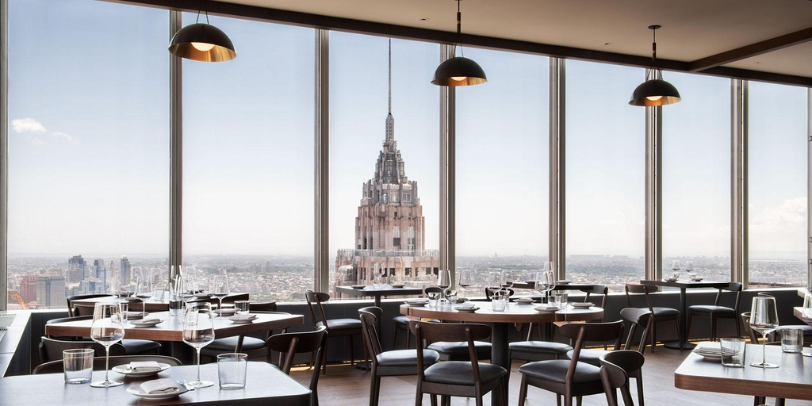

## Motivation

Our communities are critical to our lives as residents of New York City’s diverse boroughs. Each neighborhood has its own unique character, population, and resources, which in turn impact the experiences and well-being of its residents. As New Yorkers, we want to live in neighborhoods that are healthy, vibrant, and thriving. One key indicator of a healthy community is food safety, since restaurants play a critical role in public health and day-to-day life. Restaurants not only provide nutrition but also contribute to social life, employment, and the local economy.

This project addresses a crucial question for New Yorkers: How does restaurant quality relate to community health across New York City’s neighborhoods? Understanding how poor restaurant quality, whether due to low food quality, a high prevalence of fast food, or frequent critical health violations, may affect our community health is important. Poor restaurant quality could be linked to higher rates of diet-related conditions like diabetes, obesity, and other chronic illnesses, which have long-term implications for individuals and the healthcare system.

Economic factors may also play a role in restaurant quality. Neighborhoods with higher poverty rates or greater rent burdens could face more challenges in supporting high-quality restaurant options. This could lead to a higher prevalence of fast food or restaurants with poor health inspection results. Exploring these patterns can help identify whether economic stress in a community is linked to poorer food quality choices and, in turn, public health outcomes.

By examining these relationships, we aim to provide insights that inform public health policies, guide interventions, and support access to safe and nutritious food across all neighborhoods. Understanding these patterns can empower communities and policymakers to take actions that promote safer, healthier, and more vibrant communities for all New Yorkers.

## Analysis

To address our overarching question, we broke the problem into four specific questions, each looking at a different way restaurant quality and community health might be connected. Together, these analyses helped us to move beyond a single definition of “restaurant quality” and instead position it within economic, nutritional, and public health contexts.

First, we looked at whether neighborhood economic conditions are related to restaurant inspection outcomes, focusing on poverty and other socioeconomic indicators. This allowed us to see whether lower inspection grades are more common in economically disadvantaged neighborhoods. If that pattern existed, it suggested that restaurant quality may be influenced by broader structural resource constraints rather than isolated individual restaurant behavior. This provided important context for understanding differences in food safety across neighborhoods.

Second, we explored whether neighborhood health outcomes, such as obesity and diabetes prevalence, were associated with the local food environment, measured through the share of American-style cuisine restaurants. This analysis expanded the concept of restaurant quality to include nutritional context, assessing whether communities facing higher rates of chronic disease also experienced more limited or less diverse food options. By doing so, we connected restaurant characteristics not only to immediate safety concerns but also to longer-term health patterns within neighborhoods.

Third, we examined whether neighborhoods with poorer restaurant inspection grades tended to have higher numbers of 311 food poisoning complaints. This analysis directly tested whether regulatory measures of restaurant quality aligned with residents’ reported food safety experiences. By comparing inspection outcomes with complaint data, we assessed whether lower inspection grades corresponded to increased acute food-related illness reports, or whether other factors, such as population density or reporting behavior, played a larger role.

Finally, we focused more directly on food safety risk by asking whether neighborhoods with high poverty levels also experienced more critical health violations during restaurant inspections. Critical violations are the most serious inspection findings and are the ones most closely linked to foodborne illness risk. This analysis allowed us to move beyond overall grades and look specifically at the types of violations that posed the greatest threat to public health, helping to clarify how economic disadvantage may translate into increased exposure to unsafe food conditions.

Taken together, these four analyses approach the overarching question from economic, regulatory, nutritional, and experiential perspectives. Instead of treating restaurant quality as a single indicator, our framework examined how it interacts with broader community conditions and health outcomes. This integrated approach allowed us to identify where restaurant quality reflects underlying neighborhood disadvantage, where it may contribute to both chronic and acute health risks, and where expected relationships were weaker than anticipated; thus offering a nuanced understanding of how restaurant quality and community health intersect across New York City.

## Data Sources

In order to find out the answers to the question, the team used 3 datasets from different sources. The first of these datasets is New York City Community Health Profiles from the [NYC Health Website](https://www.nyc.gov/site/doh/data/data-publications/profiles.page). This dataset was made in 2022, and is a collective sum of data from different areas of government and public organizations. These include the American Community Survey (ACS), NYC DOHMH,the NYC Department of Education, the NYC Mayor’s Office for Economic Opportunity, and the NYC Housing and Vacancy Survey (HVS). This Excel file is very comprehensive, with 6 different “pages” and the first 3 pages providing technical and metadata. The last 3 pages are community health profiles, the cause of premature death, and the ranking of cancer data. However, this study will only be using the community health profiles for analyzing due to the last 2 pages (premature death and cancer data) do not have data related to the study. The community health profiles dataset contains 59 community districts making up NYC, and over 50 different measures of public health. These measures fall under demographics, economic or societal conditions, access to health, and health outcomes. This data becomes bloated Though, it has a total of 196 columns because some measures include confidence intervals, notes about the measure, or comparing if the district is higher or lower than to the average in NYC.

This study will only use columns that relate to the question. Through this, there are only a few that remain important to the study. These include columns like poverty, hypertension, obesity, diabetes, and self-reported health. As seen below, all of these values are in percentages. There are some limitations to this data, especially as it has multiple different sources that likely used different methods to obtain the data. For example, there is a self-reported health column, which is unreliable because people could underestimate or overestimate their health condition. As well, because this data is turned into a sum or average per district, analysis cannot go further in depth. Finally, the data sources all come from different years, from 2014 to 2022. Using this data with other datasets means possibly comparing measures from 2016 to those in 2025, thus leading to inaccurate findings.

```r
ch_neighbor|>
  select(
    Name,
    Poverty, Unemployment, Rent_Burden,  Obesity, Hypertension)|>
  mutate(
    across(
      where(is.numeric) & !any_of("ID"),
      ~ percent(.x, accuracy = 0.01, scale = 1)
    )
  )|>
  rename(`Rent Burden`=Rent_Burden)|>
  datatable(options=list(pageLength=5, scrollX=TRUE),
            rownames = FALSE, selection = 'none' )
```

| Name | Poverty | Unemployment | Rent Burden | Obesity | Hypertension |
| --- | --- | --- | --- | --- | --- |
| Financial District | 7.60% | 4.00% | 35.00% | 7.86% | 20.06% |
| Greenwich Village and Soho | 7.60% | 4.00% | 35.00% | 7.86% | 20.06% |
| Lower East Side and Chinatown | 22.00% | 6.00% | 49.00% | 13.78% | 22.49% |
| Clinton and Chelsea | 11.20% | 4.00% | 39.00% | 12.14% | 12.81% |
| Midtown | 11.20% | 4.00% | 39.00% | 12.14% | 12.81% |
| Stuyvesant Town and Turtle Bay | 8.70% | 3.00% | 41.00% | 10.38% | 19.22% |
| Upper West Side | 9.50% | 4.00% | 36.00% | 21.11% | 20.32% |
| Upper East Side | 6.10% | 3.00% | 40.00% | 10.27% | 16.16% |
| Morningside Heights and Hamilton Heights | 19.90% | 6.00% | 50.00% | 22.82% | 31.00% |
| Central Harlem | 20.50% | 9.00% | 45.00% | 34.86% | 31.02% |

[output cut: 49 more lines]

The next dataset is from the [Department of Health and Mental Hygiene (DOHMH)](https://data.cityofnewyork.us/Health/DOHMH-New-York-City-Restaurant-Inspection-Results/43nn-pn8j/about_data). It contains every violation citation given out from 2015 to 2025, including letter grades, violation descriptions, location, and inspection dates. It has a total of 27 columns and 20,998 restaurants recorded, with each row being a restaurant citation. Overall, the data is complete and consistent, though the DOHMH notes that because the data is compiled from multiple data systems, there might be some illogical values. As well, the DOHMH states that “establishments with the inspection date of 1/1/1990 are new and have not received an inspection”. It is important to keep both of these statements in mind to accurately analyze this dataset. There is another limitation present, namely the lack of a district column. Although this leads to some difficulties, there is a semi-solution of using zip codes to create the district. The main issue with this is that not all zip codes correctly make up a district, meaning that analyzing at the district level means some values like the number of restaurants in that district, might be inflated or deflated compared to the actual number.

The final dataset is from NYC’s [311 Food Poisoning service request records](https://data.cityofnewyork.us/Social-Services/food-poisoning/gjkf-etq5/about_data). It contains site‑specific complaints residents submit to 311 when they believe an illness resulted from food consumed at an establishment or event. These records are part of a citywide feed that is automatically refreshed and covers requests from 2010 to the present, meaning it will be easier to use data from the same year as the previous datasets. In terms of structure, the table includes multiple 311 fields that are useful for analysis and joining. This includes Created and Closed Date, Complaint Type, Location Type, Address, Borough, and Status. For our question, these complaints serve as an approximate indicator of suspected food‑borne illness at the neighborhood level.

This dataset also has multiple limitations. First, 311 submissions are self‑reported and may reflect perception or recall bias. For example, the food item or venue people identify might not be the actual source of the illness. NYC311 explicitly notes that while reports are investigated, not every establishment is inspected before its next scheduled inspection, so a complaint does not guarantee an immediate site visit. Additionally, this dataset has a similar issue to the previous one, where there is no district column. Now, there is the “City” column that ranges from indicating New York to a borough like Flushing but it does not include district. We can also group these semi-correctly into districts by using ZIP codes in order to compare with the Community Health Profile dataset.

## Visualize Findings

There is a significant correlation between the economic stress (unemployment, poverty, and rent burden). The chart shows the expected percent of grade with economic stress, and the higher the stress becomes, districts tend to get fewer A grades and more B and C grades.

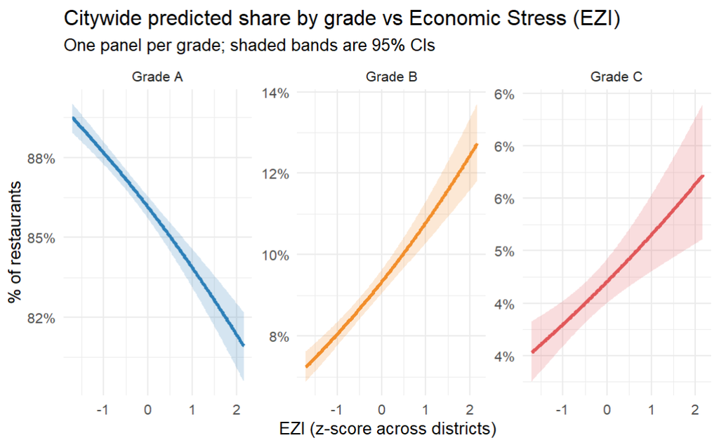

There is no meaningful relationship between restaurant inspection grades and the number of 311 food poisoning complaints at the neighborhood level. Restaurant inspection grades do not predict how many food poisoning complaints a neighborhood will receive.

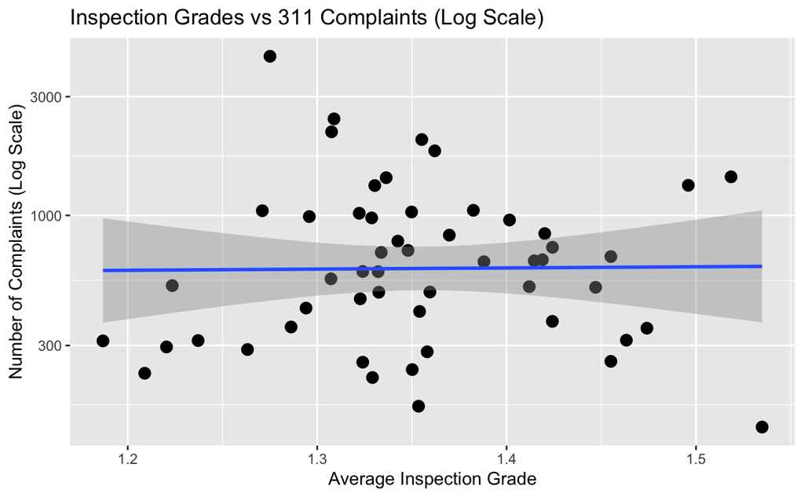

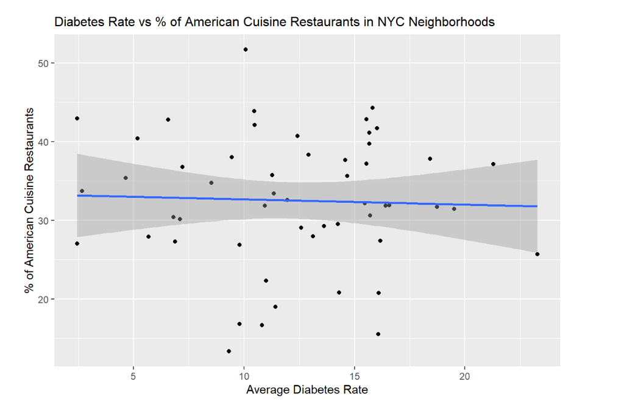

The scatter plot below shows little to no relationship between poverty rates and the rate of critical restaurant health violations. Community districts with both low and high poverty levels exhibit a wide range of critical violation rates, indicating variability that is not explained by poverty alone. The lack of a clear trend indicates that serious food safety violations occur across neighborhoods regardless of economic conditions.

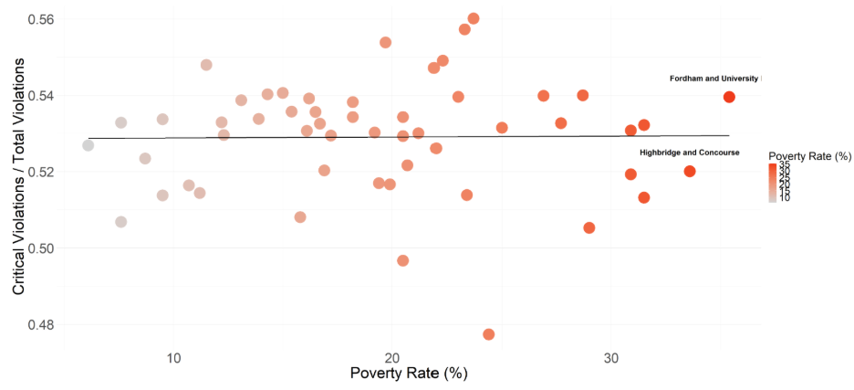

## Prior Work

Current research and literature on food safety practices for restaurants shows that better inspection outcomes is correlated with better community health. According to the [CDC,](https://www.cdc.gov/restaurant-food-safety/php/practices/outbreak-rates.html) communities experience fewer foodborne outbreaks when health departments require restaurants to post inspection results on-site and use letter grades in inspection results. These results were found from two studies where researchers surveyed health departments on their inspection practices in March of 2024 and linked the results to local outbreaks and food safety outcomes.

## Next Steps

Future work could build on this project by incorporating additional years of community health data to address temporal limitations across datasets. Although the datasets overlapped, the community health indicators were only available through 2022, which constrained longitudinal analysis. Expanding the timeframe would allow for more robust trend analysis and enable analyses such as examining how average restaurant inspection grades vary by borough and change over time.

Another important extension would be a focused study on repeated health code violations and violation patterns across restaurants, disaggregated by borough, neighborhood, or season. Examining whether certain violations recur more frequently in specific geographic areas or during particular times of the year could provide deeper insight into systemic food safety issues. Additionally, incorporating qualitative research—such as surveys or interviews with residents and restaurant owners—could help contextualize why some neighborhoods exhibit lower community health indicators and higher violation rates.

Further analyses could explore how community-level factors interact with restaurant inspection outcomes rather than just economic factors. Potential research questions include examining the relationship between other community health indicators and inspection grades, such as the ratio of farmers markets to bodegas and supermarkets, racial and ethnic diversity, levels of gentrification, and environmental factors such as air pollution. While this project conducted cross-dataset analysis, future work could more explicitly model interactions between these variables to better understand their combined effects.

Finally, these expanded analyses could inform evidence-based policy recommendations for NYC agencies, particularly the Department of Health, to improve food safety, reduce repeat violations, and address broader neighborhood-level health disparities.

## Further Discussion

The following section links to each team member’s individual report, which examines a specific research question in greater detail.

**Matthew Kelsall**: [High Poverty Rates & Critical Health Violations](https://mkels31.github.io/STA9750-2025-FALL/indiv_project.html)

**Tyler Lara**: [Economic Indicators & Restaurant Inspection Grades](https://tylerml71.github.io/STA9750-2025-FALL/Final-Individual-Report.html)

**Haley Vargas**: [Correlation of American Restaurants with Diabetes & Obesity](https://haley-vargas1.github.io/STA9750-2025-FALL/final_individual_report.html)

**Caroline Guirand**: [311 Food Poisining Complaints](https://cguirand27.github.io/STA9750-2025-FALL/STA9750_Group_Project-%20Kitchen%20Nightmares%20-%20SQ3%20Analysis.html)